# Spring 2023 GE 461 Introduction to Data Science

#### Emre Can Şen (21902516) & Serkan Uygun (21902916)

```r
##library(RSQLite)  ## if package is not on the computer, then install it only once using Tools > Install packages...
##con <- dbConnect(SQLite(), "../data/dodgers.sqlite") # read Modern Data Science with R for different ways to connect a database.
library(RSQLite)
con <- dbConnect(SQLite(), "C:/Users/Emre/Downloads/dodgers.sqlite")

## dbListTables(con)

tbl(con, "events") %>%
  collect() %>%
  mutate(day_of_week = factor(day_of_week, levels = c("Monday", "Tuesday", "Wednesday", "Thursday", "Friday", "Saturday", "Sunday")),
         month = factor(month, levels = c("APR","MAY","JUN","JUL","AUG","SEP","OCT"))) %>%
  mutate_if(is.character, factor) %>%
  mutate(temp = round((temp- 32)*5/9)) -> events
```

## Variable Analysis

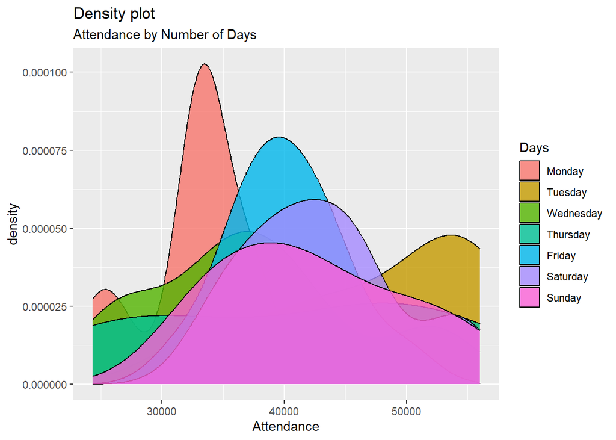

```r
g <- events %>%  ggplot(aes(attend))
g + geom_density(aes(fill=factor(day_of_week)), alpha=0.8) +
    labs(title="Density plot",
         subtitle="Attendance by Number of Days",
         x="Attendance",
         fill="Days")
```

This graph shows the density distribution days with regards to attendance. Some days are more homogeneous like Fridays, compared to some days like Mondays, where there is a peak distribution around 33k attendance. This graph might highlight some correlation for the reason between attendance and day of the weeks that will be examined in the coming sections.

Then relationship of variables that were not covered in the class with regards to attendance were examined.

```r
lmod05 <- lm(attend ~ cap, data = events)
lmod05 %>% summary()
```

```
##
## Call:
## lm(formula = attend ~ cap, data = events)
##
## Residuals:
##      Min       1Q   Median       3Q      Max
## -16800.2  -5521.2   -828.2   5475.8  14887.8
##
## Coefficients:
##             Estimate Std. Error t value            Pr(>|t|)
## (Intercept)    41112        938   43.83 <0.0000000000000002 ***
## capYES         -2923       5970   -0.49               0.626
## ---
## Signif. codes:  0 '***' 0.001 '**' 0.01 '*' 0.05 '.' 0.1 ' ' 1
##
## Residual standard error: 8337 on 79 degrees of freedom
## Multiple R-squared:  0.003025,   Adjusted R-squared:  -0.009595
## F-statistic: 0.2397 on 1 and 79 DF,  p-value: 0.6258
```

```r
#lmod05 %>% plot()
```

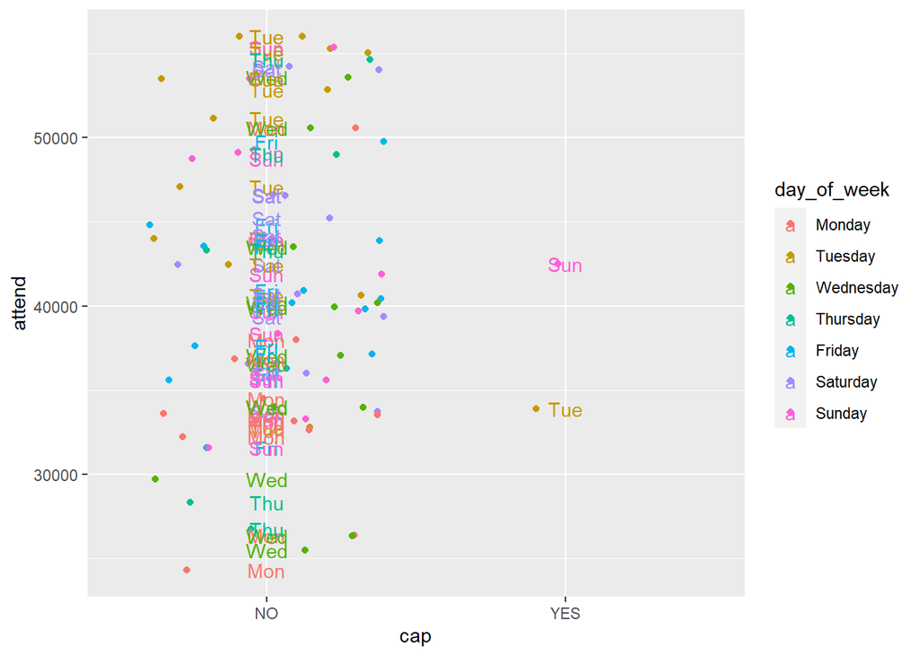

```r
events %>%
  ggplot(aes(cap, attend)) +
  geom_jitter(aes(col = day_of_week)) +
  geom_text(aes(label = str_sub(day_of_week, 1,3), col = day_of_week)) +
  geom_smooth(se = FALSE)
```

```r
t.test(x=events$attend[events$cap=="NO"],
       y=events$attend[events$cap=="YES"])
```

```
##
##  Welch Two Sample t-test
##
## data:  events$attend[events$cap == "NO"] and events$attend[events$cap == "YES"]
## t = 0.66319, df = 1.0977, p-value = 0.619
## alternative hypothesis: true difference in means is not equal to 0
## 95 percent confidence interval:
##  -42563.39  48408.87
## sample estimates:
## mean of x mean of y
##  41112.24  38189.50
```

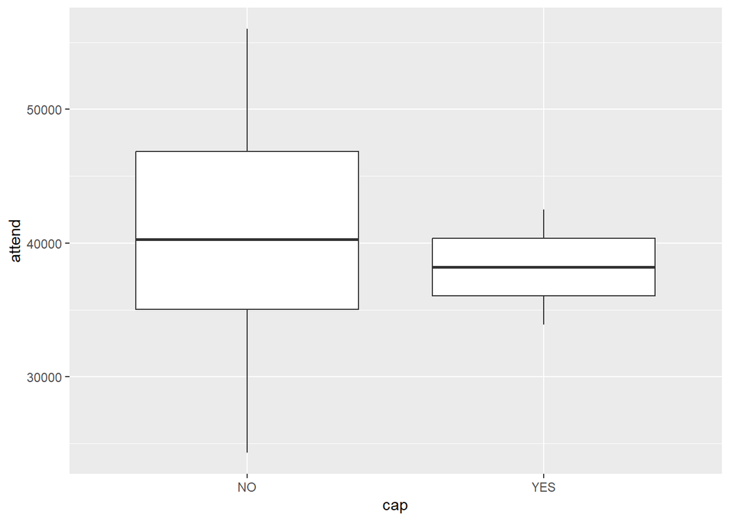

```r
events %>%
  ggplot(aes(cap, attend)) +
  geom_boxplot()
```

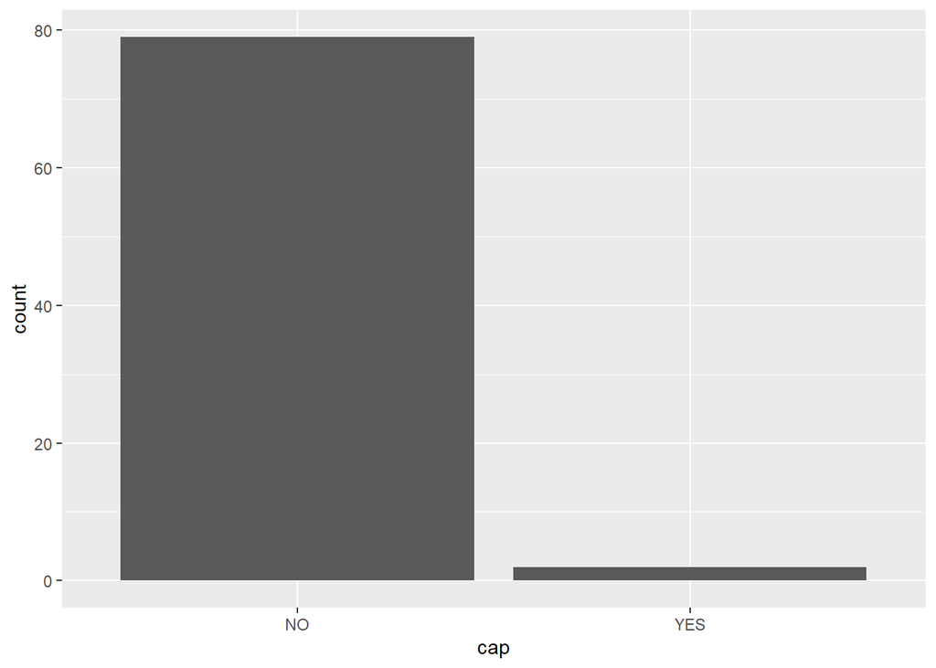

```r
events %>%
  ggplot(aes(cap)) +
  geom_bar(aes(fill=attend))
```

The no cap days include more days and consequently we have more data about its spread within the day of the week, but since there are just two cap days same can’t be said for this case. The data is heavily skewed towards no cap days. Since there is a discrepancy in the data with the cap and without the cap, the conclusion derived from this data will be biased. So cap data entered to the model might introduce biased conclusions. As seen in the graph, the average attendance with cap days is lower than no caps days. The p-value of caps is high, so the null hypotheses is passed that there is no relation between caps and attendance. Also there isn’t a significant statistical difference in average attendance with or without caps shown by the Welch Two Sample Test.

```r
lmod06 <- lm(attend ~ shirt, data = events)
lmod06 %>% summary()
```

```
##
## Call:
## lm(formula = attend ~ shirt, data = events)
##
## Residuals:
##      Min       1Q   Median       3Q      Max
## -16512.6  -6331.6   -651.6   4385.4  15175.4
##
## Coefficients:
##             Estimate Std. Error t value            Pr(>|t|)
## (Intercept)    40825        937  43.569 <0.0000000000000002 ***
## shirtYES        5819       4869   1.195               0.236
## ---
## Signif. codes:  0 '***' 0.001 '**' 0.01 '*' 0.05 '.' 0.1 ' ' 1
##
## Residual standard error: 8275 on 79 degrees of freedom
## Multiple R-squared:  0.01776,    Adjusted R-squared:  0.005327
## F-statistic: 1.428 on 1 and 79 DF,  p-value: 0.2356
```

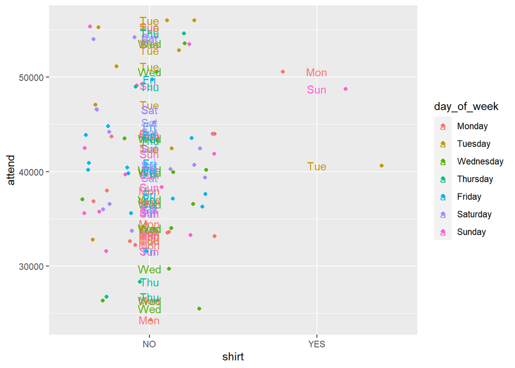

```r
events %>%
  ggplot(aes(shirt, attend)) +
  geom_jitter(aes(col = day_of_week)) +
  geom_text(aes(label = str_sub(day_of_week, 1,3), col = day_of_week)) +
  geom_smooth(se = FALSE)
```

```r
t.test(x=events$attend[events$shirt=="NO"],
       y=events$attend[events$shirt=="YES"])
```

```
##
##  Welch Two Sample t-test
##
## data:  events$attend[events$shirt == "NO"] and events$attend[events$shirt == "YES"]
## t = -1.8187, df = 2.3992, p-value = 0.1891
## alternative hypothesis: true difference in means is not equal to 0
## 95 percent confidence interval:
##  -17607.94   5969.71
## sample estimates:
## mean of x mean of y
##  40824.55  46643.67
```

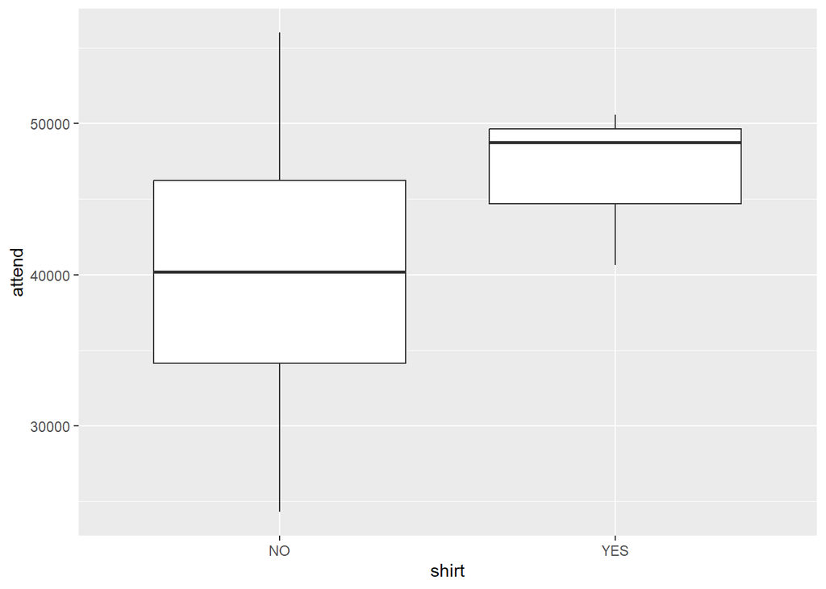

```r
events %>%
  ggplot(aes(shirt, attend)) +
  geom_boxplot()
```

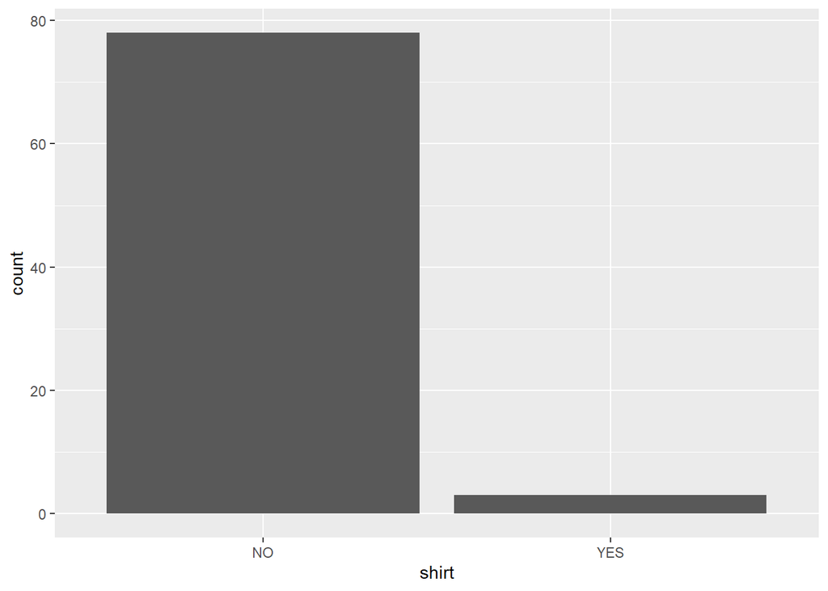

```r
events %>%
  ggplot(aes(shirt)) +
  geom_bar(aes(fill=attend))
```

Same situation with the cap case, less shirt days than no shirt days, as a consequence of insufficient data the conclusion drawn from the data will introduce bias and possibly error.The p-value of shirts is high, so the null hypotheses is passed that there is no relation between shirts and attendance. Also as seen in the graph, the average attendance with shirt days is higher than no shirt days.

```r
lmod07 <- lm(attend ~ fireworks, data = events)
lmod07 %>% summary()
```

```
##
## Call:
## lm(formula = attend ~ fireworks, data = events)
##
## Residuals:
##      Min       1Q   Median       3Q      Max
## -16720.2  -6539.2   -748.2   5555.8  14967.8
##
## Coefficients:
##              Estimate Std. Error t value            Pr(>|t|)
## (Intercept)  41032.18    1020.10  40.224 <0.0000000000000002 ***
## fireworksYES    45.68    2453.70   0.019               0.985
## ---
## Signif. codes:  0 '***' 0.001 '**' 0.01 '*' 0.05 '.' 0.1 ' ' 1
##
## Residual standard error: 8350 on 79 degrees of freedom
## Multiple R-squared:  4.387e-06,  Adjusted R-squared:  -0.01265
## F-statistic: 0.0003466 on 1 and 79 DF,  p-value: 0.9852
```

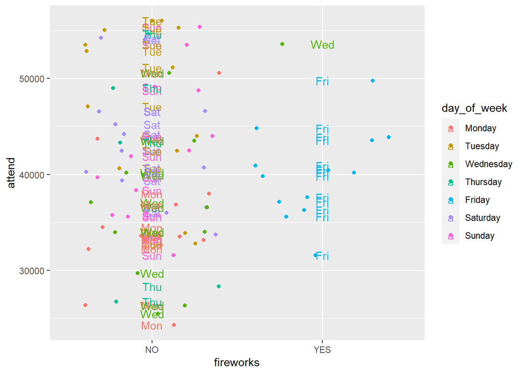

```r
events %>%
  ggplot(aes(fireworks, attend)) +
  geom_jitter(aes(col = day_of_week)) +
  geom_text(aes(label = str_sub(day_of_week, 1,3), col = day_of_week)) +
  geom_smooth(se = FALSE)
```

```r
t.test(x=events$attend[events$fireworks=="NO"],
       y=events$attend[events$fireworks=="YES"])
```

```
##
##  Welch Two Sample t-test
##
## data:  events$attend[events$fireworks == "NO"] and events$attend[events$fireworks == "YES"]
## t = -0.024331, df = 27.332, p-value = 0.9808
## alternative hypothesis: true difference in means is not equal to 0
## 95 percent confidence interval:
##  -3895.500  3804.144
## sample estimates:
## mean of x mean of y
##  41032.18  41077.86
```

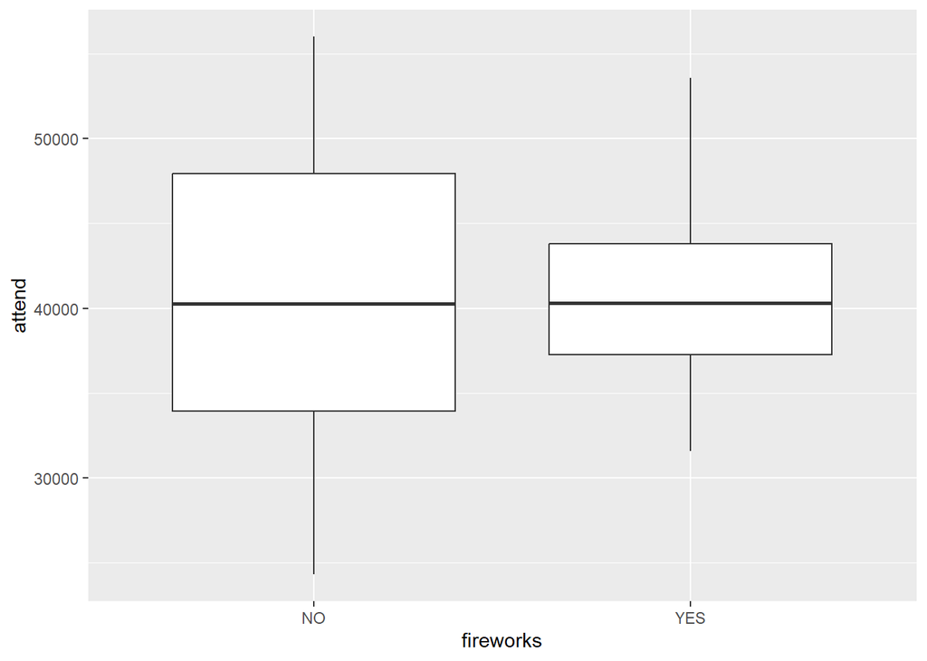

```r
events %>%
  ggplot(aes(fireworks, attend)) +
  geom_boxplot()
```

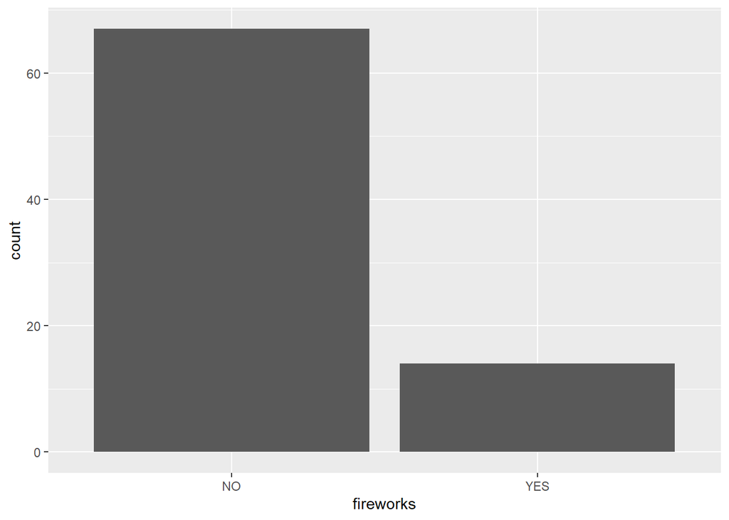

```r
events %>%
  ggplot(aes(fireworks)) +
  geom_bar(aes(fill=attend))
```

There is more data in fireworks compared to two previous cases, and the days with fireworks mainly consist of Fridays. As seen in the graph, the average attendance with fireworks days is indifferent than no fireworks days. The p-value of fireworks is high, so the null hypotheses is passed that there is no relation between fireworks and attendance. Also there isn’t a significant statistical difference in average attendance with or without fireworks shown by the Welch Two Sample Test.

```r
lmod08 <- lm(attend ~ bobblehead, data = events)
lmod08 %>% summary()
```

```
##
## Call:
## lm(formula = attend ~ bobblehead, data = events)
##
## Residuals:
##      Min       1Q   Median       3Q      Max
## -14825.9  -5123.9    667.1   4171.1  16862.1
##
## Coefficients:
##               Estimate Std. Error t value             Pr(>|t|)
## (Intercept)    39137.9      811.6   48.22 < 0.0000000000000002 ***
## bobbleheadYES  14006.7     2202.5    6.36         0.0000000122 ***
## ---
## Signif. codes:  0 '***' 0.001 '**' 0.01 '*' 0.05 '.' 0.1 ' ' 1
##
## Residual standard error: 6791 on 79 degrees of freedom
## Multiple R-squared:  0.3386, Adjusted R-squared:  0.3302
## F-statistic: 40.44 on 1 and 79 DF,  p-value: 0.00000001217
```

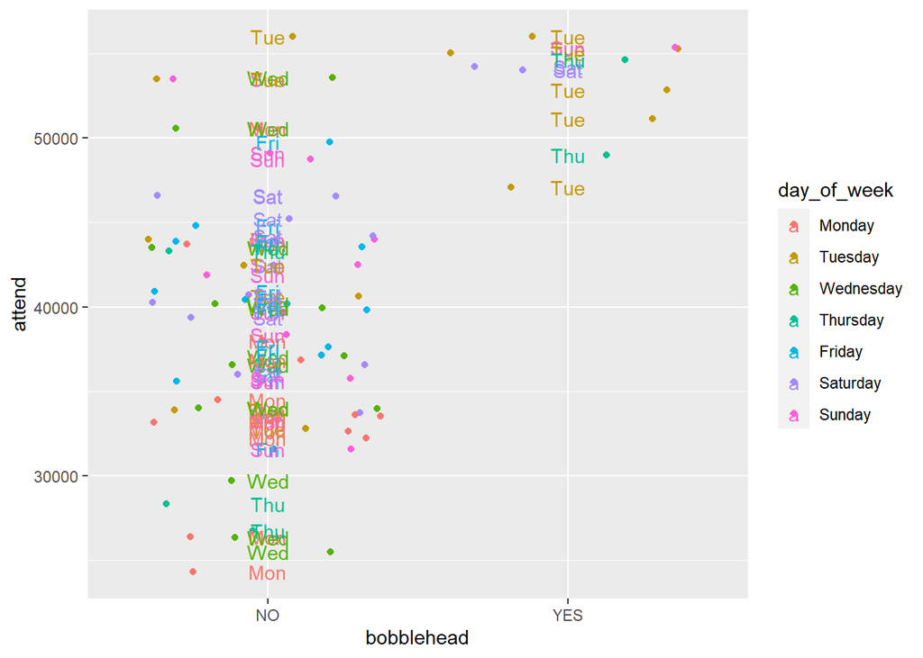

```r
events %>%
  ggplot(aes(bobblehead, attend)) +
  geom_jitter(aes(col = day_of_week)) +
  geom_text(aes(label = str_sub(day_of_week, 1,3), col = day_of_week)) +
  geom_smooth(se = FALSE)
```

In the bobblehead data, the average attendance increase is greater than the other variables and this is the only variable that fails the null hypotheses showing some correlation with the attendance.

```r
t.test(x=events$attend[events$bobblehead=="NO"],
       y=events$attend[events$bobblehead=="YES"])
```

```
##
##  Welch Two Sample t-test
##
## data:  events$attend[events$bobblehead == "NO"] and events$attend[events$bobblehead == "YES"]
## t = -11.456, df = 34.218, p-value = 0.000000000000294
## alternative hypothesis: true difference in means is not equal to 0
## 95 percent confidence interval:
##  -16490.75 -11522.66
## sample estimates:
## mean of x mean of y
##  39137.93  53144.64
```

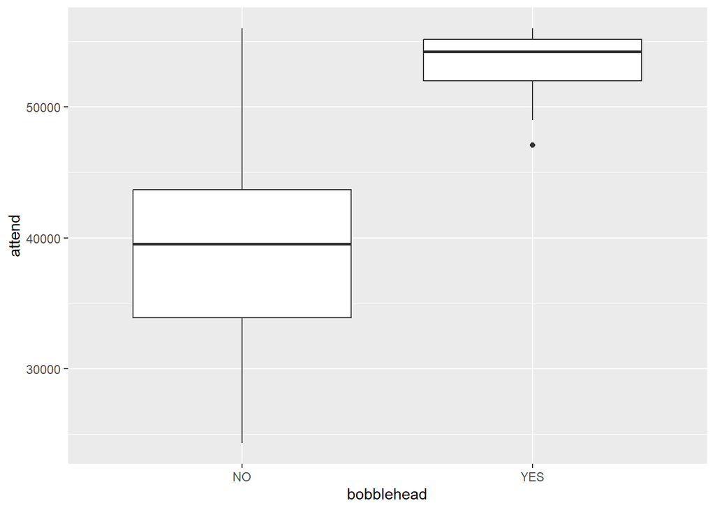

```r
events %>%
  ggplot(aes(bobblehead, attend)) +
  geom_boxplot()
```

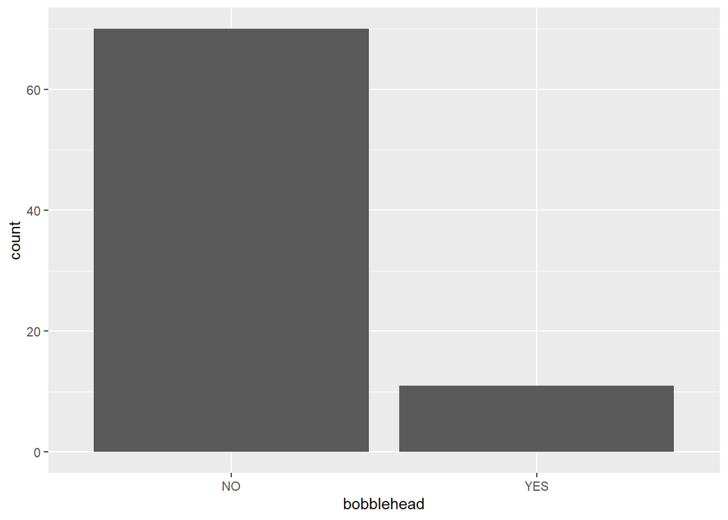

```r
events %>%
  ggplot(aes(bobblehead)) +
  geom_bar(aes(fill=attend))
```

```r
lmod09 <- lm(attend ~ opponent, data = events)
lmod09 %>% summary()
```

```
##
## Call:
## lm(formula = attend ~ opponent, data = events)
##
## Residuals:
##    Min     1Q Median     3Q    Max
## -15003  -5369  -1172   3152  17981
##
## Coefficients:
##                   Estimate Std. Error t value             Pr(>|t|)
## (Intercept)        49777.3     4620.0  10.774 0.000000000000000515 ***
## opponentAstros    -14394.0     6533.7  -2.203              0.03120 *
## opponentBraves    -17532.3     6533.7  -2.683              0.00927 **
## opponentBrewers   -14418.6     6111.7  -2.359              0.02138 *
## opponentCardinals  -8924.0     5522.0  -1.616              0.11099
## opponentCubs       -5570.7     6533.7  -0.853              0.39706
## opponentGiants    -10481.0     5334.7  -1.965              0.05380 .
## opponentMarlins    -9112.0     6533.7  -1.395              0.16795
## opponentMets        -191.1     6111.7  -0.031              0.97516
## opponentNationals   -510.0     6533.7  -0.078              0.93803
## opponentPadres     -7685.1     5334.7  -1.441              0.15458
## opponentPhillies   -7880.3     6533.7  -1.206              0.23222
## opponentPirates   -11758.3     6533.7  -1.800              0.07663 .
## opponentReds       -9128.3     6533.7  -1.397              0.16720
## opponentRockies   -10146.1     5334.7  -1.902              0.06169 .
## opponentSnakes    -10461.9     5334.7  -1.961              0.05422 .
## opponentWhite Sox  -3395.3     6533.7  -0.520              0.60509
## ---
## Signif. codes:  0 '***' 0.001 '**' 0.01 '*' 0.05 '.' 0.1 ' ' 1
##
## Residual standard error: 8002 on 64 degrees of freedom
## Multiple R-squared:  0.256,  Adjusted R-squared:  0.06994
## F-statistic: 1.376 on 16 and 64 DF,  p-value: 0.1825
```

For some opponents the null hypotheses is rejected but for some its not. This might be due to the hype of the game and corresponding teams ability to generate hype. Some teams might be favored in the last model.

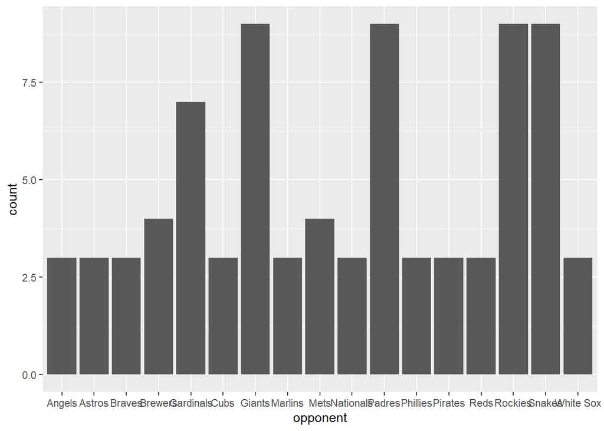

```r
events %>%
  ggplot(aes(opponent)) +
  geom_bar(aes(fill=attend))
```

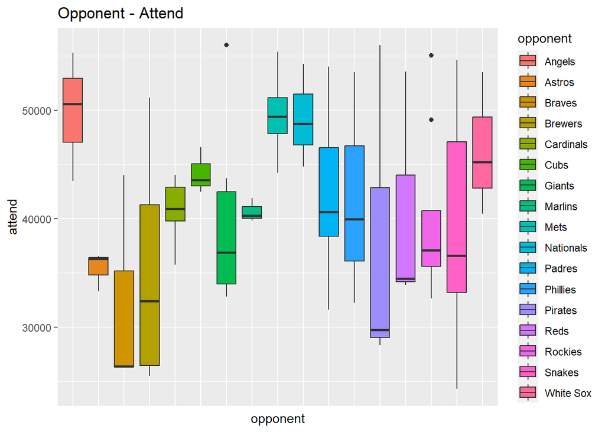

```r
d <- dbReadTable(con, "events")

opponentmod <- ggplot(d, aes(x = opponent, y = attend, fill = opponent)) +
   geom_boxplot() +
   theme(axis.text.x=element_blank(),
   axis.ticks.x=element_blank()) +
   ggtitle("Opponent - Attend ")
opponentmod
```

Some opponents have higher attendance that others, this spread in the data might be the reason for the acceptance of null hypotheses. This might suggest that although some opponents have an effect on attendance, because of other teams diminished effects, their effect might get lost in the data. Hence the null hypotheses.

```r
lmod10 <- lm(attend ~ day_night*temp, data = events)
lmod10 %>% summary()
```

```
##
## Call:
## lm(formula = attend ~ day_night * temp, data = events)
##
## Residuals:
##      Min       1Q   Median       3Q      Max
## -15250.7  -5892.4   -698.4   5253.2  15716.3
##
## Coefficients:
##                     Estimate Std. Error t value   Pr(>|t|)
## (Intercept)          62830.8    11788.6   5.330 0.00000095 ***
## day_nightNight      -30886.2    12835.1  -2.406     0.0185 *
## temp                  -828.2      456.7  -1.813     0.0737 .
## day_nightNight:temp   1229.2      508.5   2.417     0.0180 *
## ---
## Signif. codes:  0 '***' 0.001 '**' 0.01 '*' 0.05 '.' 0.1 ' ' 1
##
## Residual standard error: 8114 on 77 degrees of freedom
## Multiple R-squared:  0.07963,    Adjusted R-squared:  0.04377
## F-statistic: 2.221 on 3 and 77 DF,  p-value: 0.09244
```

Although the significance level of day-night and temperature is lower, correlation can be observed between day-night and temperature data, for natural reasons at 10% significant level.

```r
lmod11 <- lm(attend ~ opponent*bobblehead, data = events)
lmod11 %>% summary()
```

```
##
## Call:
## lm(formula = attend ~ opponent * bobblehead, data = events)
##
## Residuals:
##     Min      1Q  Median      3Q     Max
## -9691.0 -3215.4  -381.3  2773.8 17981.0
##
## Coefficients: (9 not defined because of singularities)
##                                 Estimate Std. Error t value            Pr(>|t|)
## (Intercept)                      47026.5     4479.4  10.499 0.00000000000000761
## opponentAstros                  -11643.2     5782.8  -2.013             0.04889
## opponentBraves                  -14781.5     5782.8  -2.556             0.01333
## opponentBrewers                 -16927.2     5782.8  -2.927             0.00494
## opponentCardinals                -6173.2     5079.1  -1.215             0.22931
## opponentCubs                     -2819.8     5782.8  -0.488             0.62772
## opponentGiants                   -9818.1     5008.1  -1.960             0.05492
## opponentMarlins                  -6361.2     5782.8  -1.100             0.27603
## opponentMets                       -36.5     6334.8  -0.006             0.99542
## opponentNationals                 -246.5     6334.8  -0.039             0.96910
## opponentPadres                   -6424.5     5008.1  -1.283             0.20484
## opponentPhillies                 -5129.5     5782.8  -0.887             0.37886
## opponentPirates                  -9007.5     5782.8  -1.558             0.12495
## opponentReds                     -6377.5     5782.8  -1.103             0.27482
## opponentRockies                  -9319.4     5008.1  -1.861             0.06801
## opponentSnakes                  -13808.3     5172.3  -2.670             0.00992
## opponentWhite Sox                 -644.5     5782.8  -0.111             0.91166
## bobbleheadYES                     8252.5     7758.5   1.064             0.29204
## opponentAstros:bobbleheadYES          NA         NA      NA                  NA
## opponentBraves:bobbleheadYES          NA         NA      NA                  NA
## opponentBrewers:bobbleheadYES    12785.2    10663.0   1.199             0.23557
## opponentCardinals:bobbleheadYES       NA         NA      NA                  NA
## opponentCubs:bobbleheadYES            NA         NA      NA                  NA
## opponentGiants:bobbleheadYES     10539.1    10263.5   1.027             0.30890
## opponentMarlins:bobbleheadYES         NA         NA      NA                  NA
## opponentMets:bobbleheadYES       -3060.0    10016.1  -0.306             0.76111
## opponentNationals:bobbleheadYES   -790.5    10972.1  -0.072             0.94282
## opponentPadres:bobbleheadYES      5159.5    10263.5   0.503             0.61714
## opponentPhillies:bobbleheadYES        NA         NA      NA                  NA
## opponentPirates:bobbleheadYES         NA         NA      NA                  NA
```

[output cut: 30 more lines]

```
## opponentMets:bobbleheadYES
## opponentNationals:bobbleheadYES
## opponentPadres:bobbleheadYES
## opponentPhillies:bobbleheadYES
## opponentPirates:bobbleheadYES
## opponentReds:bobbleheadYES
## opponentRockies:bobbleheadYES
## opponentSnakes:bobbleheadYES
## opponentWhite Sox:bobbleheadYES
## ---
## Signif. codes:  0 '***' 0.001 '**' 0.01 '*' 0.05 '.' 0.1 ' ' 1
##
## Residual standard error: 6335 on 56 degrees of freedom
## Multiple R-squared:  0.592,  Adjusted R-squared:  0.4171
## F-statistic: 3.386 on 24 and 56 DF,  p-value: 0.00008792
```

```r
lmod12 <- lm(attend ~ opponent*shirt, data = events)
lmod12 %>% summary()
```

```
##
## Call:
## lm(formula = attend ~ opponent * shirt, data = events)
##
## Residuals:
##      Min       1Q   Median       3Q      Max
## -15003.4  -5369.3   -860.3   3151.7  17981.0
##
## Coefficients: (14 not defined because of singularities)
##                            Estimate Std. Error t value         Pr(>|t|)
## (Intercept)                 49386.5     5793.2   8.525 0.00000000000552 ***
## opponentAstros             -14003.2     7479.0  -1.872           0.0660 .
## opponentBraves             -17141.5     7479.0  -2.292           0.0254 *
## opponentBrewers            -14027.8     7095.2  -1.977           0.0526 .
## opponentCardinals           -8533.2     6568.8  -1.299           0.1988
## opponentCubs                -5179.8     7479.0  -0.693           0.4912
## opponentGiants             -10090.2     6404.6  -1.575           0.1203
## opponentMarlins             -8721.2     7479.0  -1.166           0.2481
## opponentMets                  199.8     7095.2   0.028           0.9776
## opponentNationals             138.0     8192.8   0.017           0.9866
## opponentPadres              -7110.1     6477.0  -1.098           0.2766
## opponentPhillies            -7489.5     7479.0  -1.001           0.3206
## opponentPirates            -11367.5     7479.0  -1.520           0.1337
## opponentReds                -8737.5     7479.0  -1.168           0.2472
## opponentRockies             -9755.3     6404.6  -1.523           0.1329
## opponentSnakes             -10071.1     6404.6  -1.572           0.1210
## opponentWhite Sox           -3004.5     7479.0  -0.402           0.6893
## shirtYES                     1172.5    10034.1   0.117           0.9074
## opponentAstros:shirtYES          NA         NA      NA               NA
## opponentBraves:shirtYES          NA         NA      NA               NA
## opponentBrewers:shirtYES         NA         NA      NA               NA
## opponentCardinals:shirtYES       NA         NA      NA               NA
## opponentCubs:shirtYES            NA         NA      NA               NA
## opponentGiants:shirtYES          NA         NA      NA               NA
## opponentMarlins:shirtYES         NA         NA      NA               NA
## opponentMets:shirtYES            NA         NA      NA               NA
## opponentNationals:shirtYES  -1944.0    14190.3  -0.137           0.8915
## opponentPadres:shirtYES     -2829.9    13273.8  -0.213           0.8319
## opponentPhillies:shirtYES        NA         NA      NA               NA
## opponentPirates:shirtYES         NA         NA      NA               NA
## opponentReds:shirtYES            NA         NA      NA               NA
## opponentRockies:shirtYES         NA         NA      NA               NA
## opponentSnakes:shirtYES          NA         NA      NA               NA
## opponentWhite Sox:shirtYES       NA         NA      NA               NA
## ---
## Signif. codes:  0 '***' 0.001 '**' 0.01 '*' 0.05 '.' 0.1 ' ' 1
##
## Residual standard error: 8193 on 61 degrees of freedom
## Multiple R-squared:  0.2566, Adjusted R-squared:  0.02509
## F-statistic: 1.108 on 19 and 61 DF,  p-value: 0.3659
```

```r
lmod13 <- lm(attend ~ opponent*cap, data = events)
lmod13 %>% summary()
```

```
##
## Call:
## lm(formula = attend ~ opponent * cap, data = events)
##
## Residuals:
##      Min       1Q   Median       3Q      Max
## -15003.4  -5303.3   -860.3   3151.7  17981.0
##
## Coefficients: (15 not defined because of singularities)
##                          Estimate Std. Error t value            Pr(>|t|)
## (Intercept)               49777.3     4651.9  10.700 0.00000000000000102 ***
## opponentAstros           -14394.0     6578.8  -2.188              0.0325 *
## opponentBraves           -17532.3     6578.8  -2.665              0.0098 **
## opponentBrewers          -14418.6     6153.9  -2.343              0.0224 *
## opponentCardinals         -8924.0     5560.1  -1.605              0.1136
## opponentCubs              -4714.8     7355.4  -0.641              0.5239
## opponentGiants           -10481.0     5371.6  -1.951              0.0556 .
## opponentMarlins           -9112.0     6578.8  -1.385              0.1710
## opponentMets               -191.1     6153.9  -0.031              0.9753
## opponentNationals          -510.0     6578.8  -0.078              0.9385
## opponentPadres            -7685.1     5371.6  -1.431              0.1575
## opponentPhillies          -7880.3     6578.8  -1.198              0.2355
## opponentPirates          -11758.3     6578.8  -1.787              0.0788 .
## opponentReds              -5745.8     7355.4  -0.781              0.4377
## opponentRockies          -10146.1     5371.6  -1.889              0.0636 .
## opponentSnakes           -10461.9     5371.6  -1.948              0.0560 .
## opponentWhite Sox         -3395.3     6578.8  -0.516              0.6076
## capYES                   -10147.5     9868.2  -1.028              0.3078
## opponentAstros:capYES          NA         NA      NA                  NA
## opponentBraves:capYES          NA         NA      NA                  NA
## opponentBrewers:capYES         NA         NA      NA                  NA
## opponentCardinals:capYES       NA         NA      NA                  NA
## opponentCubs:capYES        7580.0    13955.8   0.543              0.5890
## opponentGiants:capYES          NA         NA      NA                  NA
## opponentMarlins:capYES         NA         NA      NA                  NA
## opponentMets:capYES            NA         NA      NA                  NA
## opponentNationals:capYES       NA         NA      NA                  NA
## opponentPadres:capYES          NA         NA      NA                  NA
## opponentPhillies:capYES        NA         NA      NA                  NA
## opponentPirates:capYES         NA         NA      NA                  NA
## opponentReds:capYES            NA         NA      NA                  NA
## opponentRockies:capYES         NA         NA      NA                  NA
## opponentSnakes:capYES          NA         NA      NA                  NA
## opponentWhite Sox:capYES       NA         NA      NA                  NA
## ---
## Signif. codes:  0 '***' 0.001 '**' 0.01 '*' 0.05 '.' 0.1 ' ' 1
##
## Residual standard error: 8057 on 62 degrees of freedom
## Multiple R-squared:  0.2692, Adjusted R-squared:  0.05705
## F-statistic: 1.269 on 18 and 62 DF,  p-value: 0.2397
```

```r
lmod11 <- lm(attend ~ opponent*fireworks, data = events)
lmod11 %>% summary()
```

```
##
## Call:
## lm(formula = attend ~ opponent * fireworks, data = events)
##
## Residuals:
##    Min     1Q Median     3Q    Max
## -15215  -5226      0   2744  17981
##
## Coefficients: (6 not defined because of singularities)
##                                Estimate Std. Error t value           Pr(>|t|)
## (Intercept)                     49777.3     4812.2  10.344 0.0000000000000254
## opponentAstros                 -14843.8     7608.7  -1.951             0.0564
## opponentBraves                 -17532.3     6805.5  -2.576             0.0128
## opponentBrewers                -14418.6     6365.9  -2.265             0.0276
## opponentCardinals               -8797.3     6087.0  -1.445             0.1543
## opponentCubs                    -5235.8     7608.7  -0.688             0.4944
## opponentGiants                 -10481.0     5556.6  -1.886             0.0648
## opponentMarlins                 -8681.8     7608.7  -1.141             0.2590
## opponentMets                     -250.0     6805.5  -0.037             0.9708
## opponentNationals                1720.2     7608.7   0.226             0.8220
## opponentPadres                  -6440.8     5751.7  -1.120             0.2678
## opponentPhillies                -7880.3     6805.5  -1.158             0.2521
## opponentPirates                -11758.3     6805.5  -1.728             0.0899
## opponentReds                   -15588.8     7608.7  -2.049             0.0454
## opponentRockies                 -9212.0     5751.7  -1.602             0.1152
## opponentSnakes                 -10250.2     5642.8  -1.817             0.0749
## opponentWhite Sox                -420.3     7608.7  -0.055             0.9562
## fireworksYES                    -8925.0    10208.2  -0.874             0.3859
## opponentAstros:fireworksYES     10274.5    14436.6   0.712             0.4798
## opponentBraves:fireworksYES          NA         NA      NA                 NA
## opponentBrewers:fireworksYES         NA         NA      NA                 NA
## opponentCardinals:fireworksYES   8481.5    12362.8   0.686             0.4957
## opponentCubs:fireworksYES        7920.5    14436.6   0.549             0.5856
## opponentGiants:fireworksYES          NA         NA      NA                 NA
## opponentMarlins:fireworksYES     7634.5    14436.6   0.529             0.5991
## opponentMets:fireworksYES        9160.7    14029.8   0.653             0.5166
## opponentNationals:fireworksYES   2234.5    14436.6   0.155             0.8776
## opponentPadres:fireworksYES      3325.4    12201.1   0.273             0.7863
## opponentPhillies:fireworksYES        NA         NA      NA                 NA
## opponentPirates:fireworksYES         NA         NA      NA                 NA
```

[output cut: 30 more lines]

```
## opponentMets:fireworksYES
## opponentNationals:fireworksYES
## opponentPadres:fireworksYES
## opponentPhillies:fireworksYES
## opponentPirates:fireworksYES
## opponentReds:fireworksYES      .
## opponentRockies:fireworksYES
## opponentSnakes:fireworksYES
## opponentWhite Sox:fireworksYES
## ---
## Signif. codes:  0 '***' 0.001 '**' 0.01 '*' 0.05 '.' 0.1 ' ' 1
##
## Residual standard error: 8335 on 53 degrees of freedom
## Multiple R-squared:  0.3315, Adjusted R-squared:  -0.009042
## F-statistic: 0.9735 on 27 and 53 DF,  p-value: 0.5173
```

```r
d_two <- d %>%
  mutate(AttendanceCat = cut(attend, breaks = 10,
                     labels=c("1","2","3","4","5","6","7","8","9","10")))

# attend column cut into five levels for chi_square tests
bobblehead_tab <- table(d_two$AttendanceCat, d_two$bobblehead)
day_of_week_tab <- table(d_two$AttendanceCat, d_two$day_of_week)
shirt_tab <- table(d_two$AttendanceCat, d_two$shirt)
opponent_tab <- table(d_two$AttendanceCat, d_two$opponent)
fireworks_tab <- table(d_two$AttendanceCat, d_two$fireworks)
temp_tab <- table(d_two$AttendanceCat, d_two$temp)
cap_tab<- table(d_two$AttendanceCat, d_two$cap)
month_table <- table(d_two$AttendanceCat, d_two$month)
day_tab <- table(d_two$AttendanceCat, d_two$day)
skies_tab <- table(d_two$AttendanceCat, d_two$skies)
day_night_tab <- table(d_two$AttendanceCat, d_two$day_night)
```

```r
pander(chisq.test(bobblehead_tab))
```

Pearson’s Chi-squared test: `bobblehead_tab`

| Test statistic | df | P value |
| --- | --- | --- |
| 40.53 | 9 | 0.000006099 * * * |

```r
pander(chisq.test(day_of_week_tab))
```

Pearson’s Chi-squared test: `day_of_week_tab`

| Test statistic | df | P value |
| --- | --- | --- |
| 63.85 | 54 | 0.1688 |

```r
pander(chisq.test(shirt_tab))
```

Pearson’s Chi-squared test: `shirt_tab`

| Test statistic | df | P value |
| --- | --- | --- |
| 10.9 | 9 | 0.2824 |

```r
pander(chisq.test(opponent_tab))
```

Pearson’s Chi-squared test: `opponent_tab`

| Test statistic | df | P value |
| --- | --- | --- |
| 193.1 | 144 | 0.003984 * * |

```r
pander(chisq.test(fireworks_tab))
```

Pearson’s Chi-squared test: `fireworks_tab`

| Test statistic | df | P value |
| --- | --- | --- |
| 7.673 | 9 | 0.5675 |

```r
pander(chisq.test(temp_tab))
```

Pearson’s Chi-squared test: `temp_tab`

| Test statistic | df | P value |
| --- | --- | --- |
| 309.6 | 279 | 0.1008 |

```r
pander(chisq.test(cap_tab))
```

Pearson’s Chi-squared test: `cap_tab`

| Test statistic | df | P value |
| --- | --- | --- |
| 4.87 | 9 | 0.8455 |

```r
pander(chisq.test(month_table))
```

Pearson’s Chi-squared test: `month_table`

| Test statistic | df | P value |
| --- | --- | --- |
| 73.69 | 54 | 0.03869 * |

```r
pander(chisq.test(day_tab))
```

Pearson’s Chi-squared test: `day_tab`

| Test statistic | df | P value |
| --- | --- | --- |
| 257.6 | 270 | 0.6958 |

```r
pander(chisq.test(skies_tab))
```

Pearson’s Chi-squared test: `skies_tab`

| Test statistic | df | P value |
| --- | --- | --- |
| 10.95 | 9 | 0.2794 |

```r
pander(chisq.test(day_night_tab))
```

Pearson’s Chi-squared test: `day_night_tab`

| Test statistic | df | P value |
| --- | --- | --- |
| 5.412 | 9 | 0.797 |

Chi-square test shows that bobblehead, opponent, and month are not mutually independent from attendance, more indication of correlation, these findings will be used in constructing the final model.

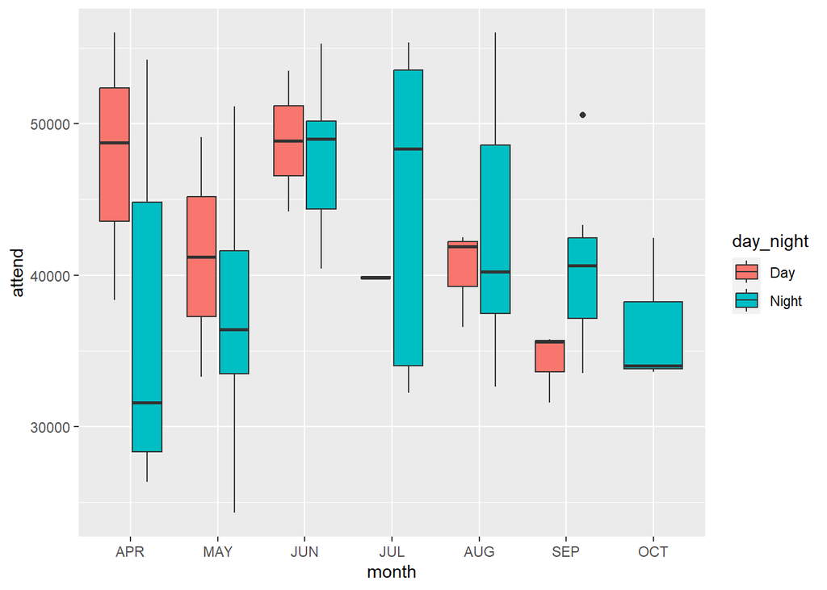

```r
events %>%
  ggplot(aes(month, attend)) +
  geom_boxplot(aes(fill = day_night))
```

When the temperature is within optimum ranges, neither too cold or too hot, the attendance difference between day and night seems to drop.

Previously in the classes it was shown that the temperature variable was found to be correlated with attendance in the pre-examination of data, but further examination of the model showed that this hypotheses was rejected later on. Same approach will be applied for all the variables in the following section.

## Building the Model

Firstly, all of the variables are plugged in for a base-line model.

```r
model0 <-lm(formula = attend ~ month + day + day_of_week + opponent +
  skies + day_night + cap + shirt + fireworks + bobblehead +
  pmax(0,temp-24), data = events)
model0 %>% summary()
```

```
##
## Call:
## lm(formula = attend ~ month + day + day_of_week + opponent +
##     skies + day_night + cap + shirt + fireworks + bobblehead +
##     pmax(0, temp - 24), data = events)
##
## Residuals:
##     Min      1Q  Median      3Q     Max
## -8392.0 -3044.4  -160.7  1725.7 11049.7
##
## Coefficients:
##                      Estimate Std. Error t value Pr(>|t|)
## (Intercept)           48652.4    12994.9   3.744 0.000522 ***
## monthMAY               3580.7     5758.5   0.622 0.537274
## monthJUN              -1818.1    11013.9  -0.165 0.869640
## monthJUL               4351.8     4760.5   0.914 0.365625
## monthAUG               9194.2     6115.8   1.503 0.139890
## monthSEP               6491.8     5447.3   1.192 0.239747
## monthOCT               8503.4     7790.9   1.091 0.281015
## day                     120.0      139.1   0.863 0.392799
## day_of_weekTuesday     7932.6     2946.4   2.692 0.010000 **
## day_of_weekWednesday   -497.2     2742.1  -0.181 0.856948
## day_of_weekThursday    -142.7     3832.9  -0.037 0.970478
## day_of_weekFriday    -19561.1     9066.4  -2.158 0.036463 *
## day_of_weekSaturday    3741.3     3278.8   1.141 0.260021
## day_of_weekSunday      1104.6     4707.2   0.235 0.815569
## opponentAstros       -19240.2    13936.5  -1.381 0.174385
## opponentBraves       -17498.8    13077.5  -1.338 0.187743
## opponentBrewers      -20267.9    14547.5  -1.393 0.170552
## opponentCardinals    -10424.7    12626.9  -0.826 0.413488
## opponentCubs         -10627.0    12258.1  -0.867 0.390677
## opponentGiants       -15534.0    12760.9  -1.217 0.229973
## opponentMarlins      -18660.1    13585.2  -1.374 0.176536
## opponentMets          -4190.2     6041.4  -0.694 0.491593
## opponentNationals     -5307.6    12753.7  -0.416 0.679312
## opponentPadres       -10766.2    10888.5  -0.989 0.328183
## opponentPhillies     -12033.7    12335.3  -0.976 0.334619
## opponentPirates      -11539.5    12801.7  -0.901 0.372283
## opponentReds         -16076.0    11631.0  -1.382 0.173898
## opponentRockies      -15163.3    12510.3  -1.212 0.231954
## opponentSnakes       -18575.6    12294.3  -1.511 0.137960
## opponentWhite Sox     -1553.7     5639.9  -0.275 0.784240
## skiesCloudy             133.1     2349.7   0.057 0.955078
## day_nightNight        -4400.9     3432.6  -1.282 0.206529
## capYES                -5343.4     5828.2  -0.917 0.364234
## shirtYES                421.0     4523.7   0.093 0.926276
## fireworksYES          21059.8     8227.2   2.560 0.013985 *
## bobbleheadYES          9721.3     3137.6   3.098 0.003386 **
## pmax(0, temp - 24)     -702.9      544.9  -1.290 0.203800
## ---
## Signif. codes:  0 '***' 0.001 '**' 0.01 '*' 0.05 '.' 0.1 ' ' 1
##
## Residual standard error: 5869 on 44 degrees of freedom
## Multiple R-squared:  0.7248, Adjusted R-squared:  0.4997
## F-statistic: 3.219 on 36 and 44 DF,  p-value: 0.0001383
```

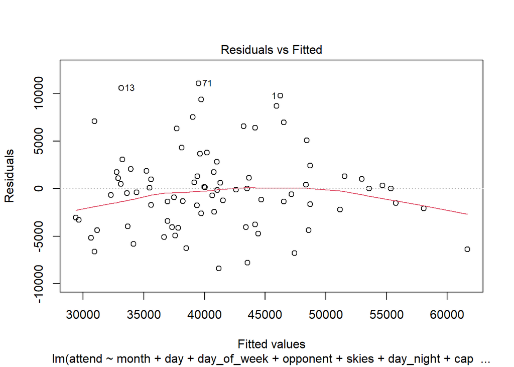

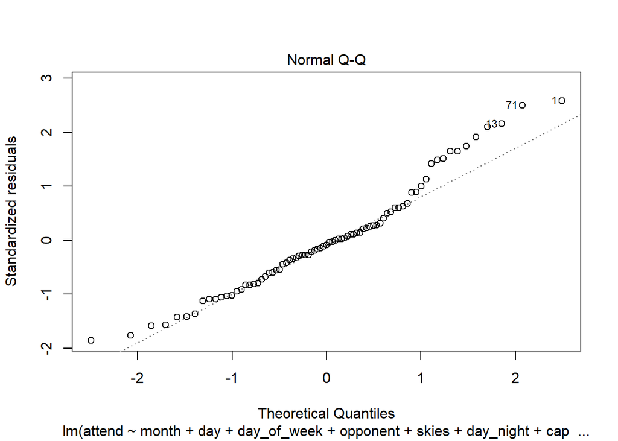

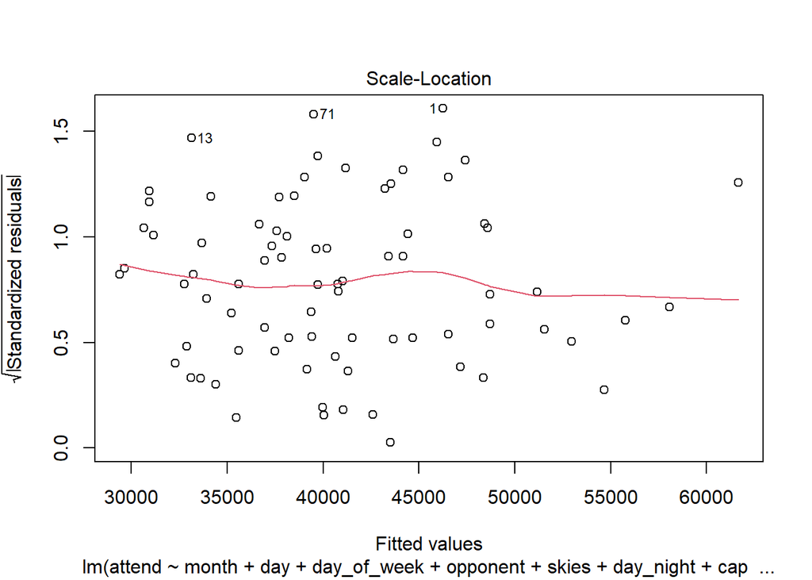

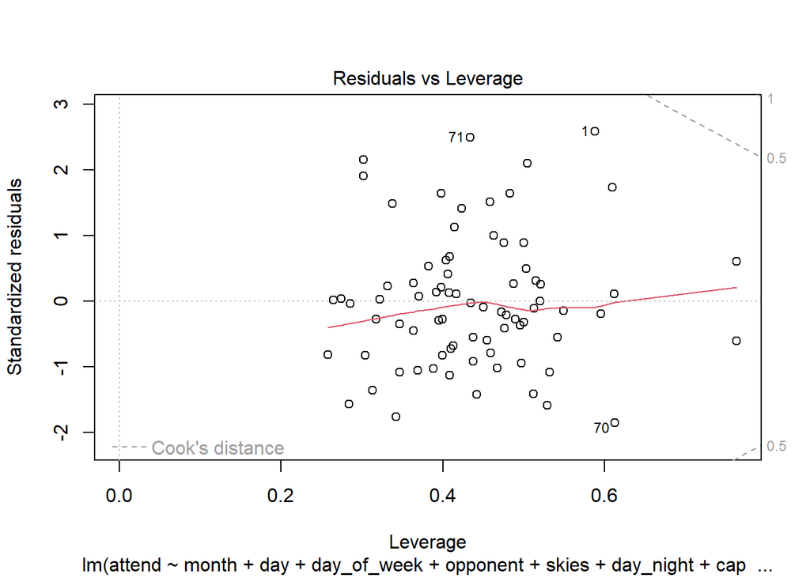

```r
plot(model0)
```

```r
AIC(model0)
```

```
## [1] 1662.189
```

Then by using the variables that were shown to be not mutually exclusive using Chi-square the second model was constructed.

```r
model1 <-lm(formula = attend ~ month + day_of_week + opponent  + bobblehead , data = events)
model1 %>% summary()
```

```
##
## Call:
## lm(formula = attend ~ month + day_of_week + opponent + bobblehead,
##     data = events)
##
## Residuals:
##      Min       1Q   Median       3Q      Max
## -11519.2  -2725.1   -364.6   1817.3  14244.3
##
## Coefficients:
##                      Estimate Std. Error t value Pr(>|t|)
## (Intercept)           37511.1    10228.9   3.667 0.000585 ***
## monthMAY               2410.9     5703.2   0.423 0.674267
## monthJUN               5484.4     9344.2   0.587 0.559841
## monthJUL               4547.5     5024.5   0.905 0.369682
## monthAUG               6814.7     6148.6   1.108 0.272917
## monthSEP               2604.2     5089.4   0.512 0.611080
## monthOCT               2399.3     7245.6   0.331 0.741900
## day_of_weekTuesday     8185.2     2944.0   2.780 0.007589 **
## day_of_weekWednesday   2107.6     2629.4   0.802 0.426514
## day_of_weekThursday     791.1     3998.5   0.198 0.843959
## day_of_weekFriday      2996.6     3330.4   0.900 0.372476
## day_of_weekSaturday    4729.9     3385.1   1.397 0.168383
## day_of_weekSunday      4771.2     3423.9   1.394 0.169509
## opponentAstros        -8704.6    10704.2  -0.813 0.419886
## opponentBraves        -8697.0    10882.1  -0.799 0.427877
## opponentBrewers       -9847.4    10300.1  -0.956 0.343559
## opponentCardinals     -2862.9    10110.5  -0.283 0.778197
## opponentCubs          -4285.0    11028.8  -0.389 0.699241
## opponentGiants        -6637.6     9980.1  -0.665 0.508991
## opponentMarlins       -7826.4    11028.8  -0.710 0.481167
## opponentMets          -1523.6     5704.9  -0.267 0.790494
## opponentNationals      4239.4    10489.8   0.404 0.687795
## opponentPadres        -2840.7     9341.3  -0.304 0.762293
## opponentPhillies      -3592.6     9896.9  -0.363 0.718107
## opponentPirates       -3186.7    11111.8  -0.287 0.775438
## opponentReds          -4840.6     9896.9  -0.489 0.626870
## opponentRockies       -6861.0     9872.4  -0.695 0.490228
## opponentSnakes        -9472.8     9472.2  -1.000 0.322001
## opponentWhite Sox      -779.4     5821.0  -0.134 0.894016
## bobbleheadYES         10052.8     3084.4   3.259 0.001992 **
## ---
## Signif. codes:  0 '***' 0.001 '**' 0.01 '*' 0.05 '.' 0.1 ' ' 1
##
## Residual standard error: 6289 on 51 degrees of freedom
## Multiple R-squared:  0.6337, Adjusted R-squared:  0.4254
## F-statistic: 3.043 on 29 and 51 DF,  p-value: 0.0002496
```

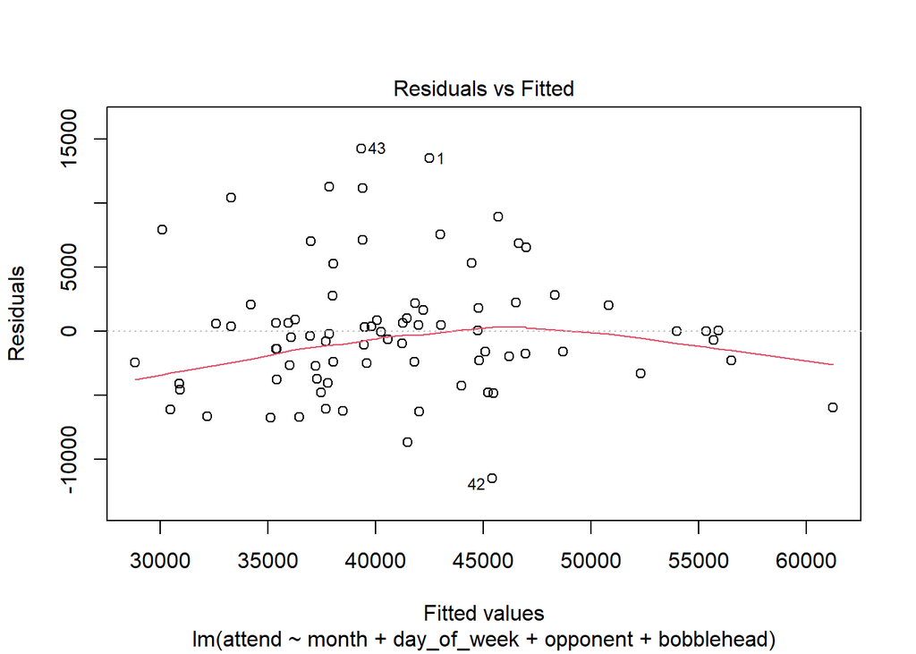

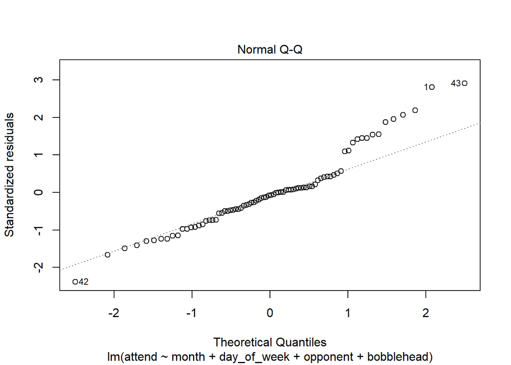

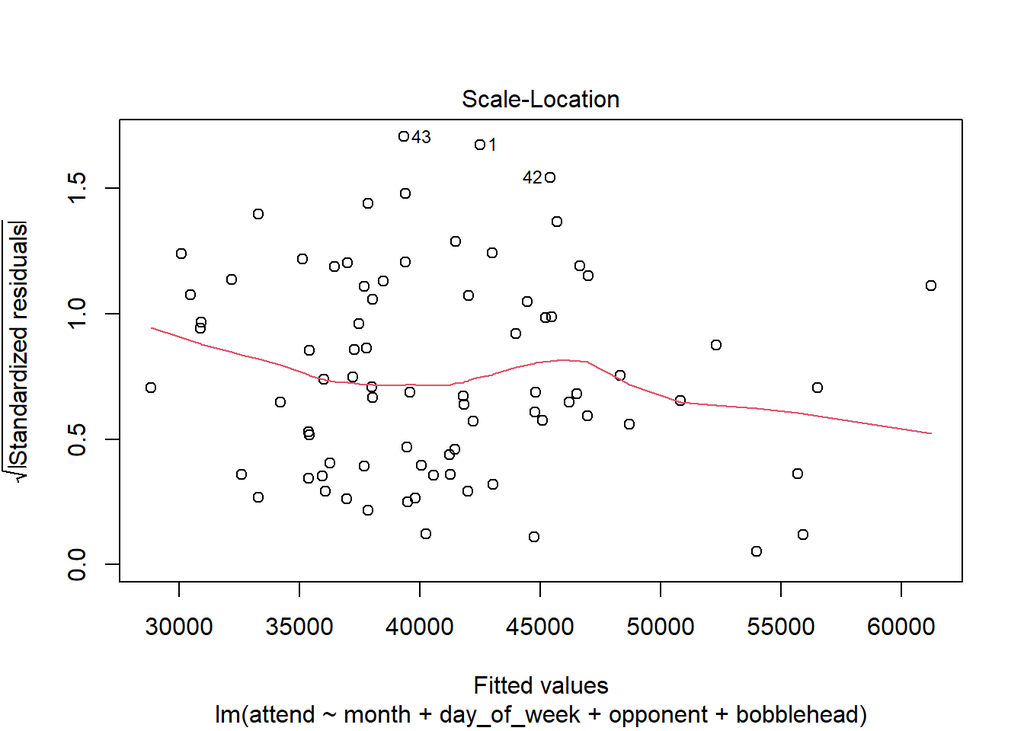

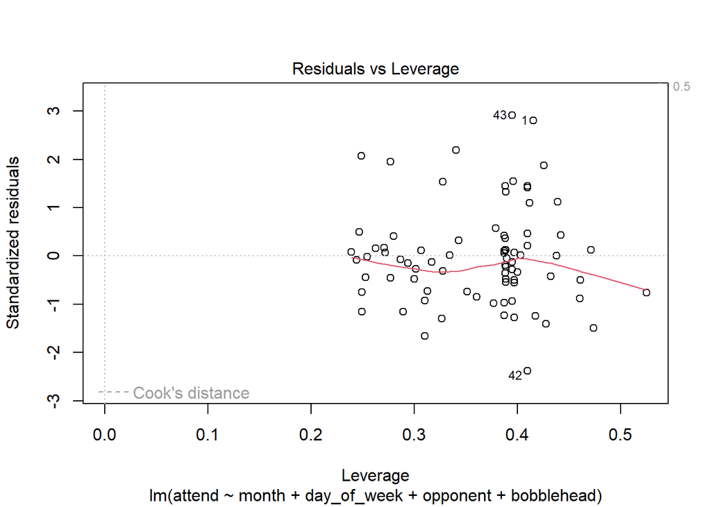

```r
plot(model1)
```

```r
AIC(model1)
```

```
## [1] 1671.35
```

```r
anova(model0,model1)
```

```
## Analysis of Variance Table
##
## Model 1: attend ~ month + day + day_of_week + opponent + skies + day_night +
##     cap + shirt + fireworks + bobblehead + pmax(0, temp - 24)
## Model 2: attend ~ month + day_of_week + opponent + bobblehead
##   Res.Df        RSS Df  Sum of Sq      F  Pr(>F)
## 1     44 1515720891
## 2     51 2017425853 -7 -501704961 2.0806 0.06586 .
## ---
## Signif. codes:  0 '***' 0.001 '**' 0.01 '*' 0.05 '.' 0.1 ' ' 1
```

These two models are statistically different, with significance level bit higher than 5 percent, but AIC score of the second model increased, which means lower capability of generalizing data. This situation is not desirable since the objective of this project is to generate a predictive model.

In order to thoroughly examine the effects of each variable all the other variables were plugged in to the model. Through checking their AIC scores the variables that lowered the score were left out, and via iterating through all the variables a new model was built. Also with ANOVA function model was updated with removed state of the iterated variables and compared. This was done to determine if the iterated variable was infact crucial for the model. For sake of readability only the check of shirt variable was left.

```r
model3 <-lm(formula = attend ~ month + day_of_week +cap +fireworks+ bobblehead , data = events)
model3 %>% summary()
```

```
##
## Call:
## lm(formula = attend ~ month + day_of_week + cap + fireworks +
##     bobblehead, data = events)
##
## Residuals:
##     Min      1Q  Median      3Q     Max
## -9518.2 -3789.8  -464.3  2974.5 15672.1
##
## Coefficients:
##                      Estimate Std. Error t value             Pr(>|t|)
## (Intercept)           34047.6     2411.2  14.121 < 0.0000000000000002 ***
## monthMAY              -2458.3     2179.2  -1.128              0.26345
## monthJUN               7217.1     2601.2   2.774              0.00721 **
## monthJUL               1980.2     2563.8   0.772              0.44269
## monthAUG               2934.3     2320.6   1.264              0.21059
## monthSEP               -112.3     2398.0  -0.047              0.96278
## monthOCT               -521.9     3848.2  -0.136              0.89253
## day_of_weekTuesday     8581.4     2640.6   3.250              0.00183 **
## day_of_weekWednesday    952.7     2460.0   0.387              0.69982
## day_of_weekThursday     734.2     3333.9   0.220              0.82640
## day_of_weekFriday    -11875.4     6866.2  -1.730              0.08846 .
## day_of_weekSaturday    6323.9     2434.7   2.597              0.01161 *
## day_of_weekSunday      7190.0     2425.6   2.964              0.00424 **
## capYES                -6201.0     4518.6  -1.372              0.17468
## fireworksYES          16589.5     6347.4   2.614              0.01112 *
## bobbleheadYES         10273.8     2362.3   4.349            0.0000492 ***
## ---
## Signif. codes:  0 '***' 0.001 '**' 0.01 '*' 0.05 '.' 0.1 ' ' 1
##
## Residual standard error: 5820 on 65 degrees of freedom
## Multiple R-squared:  0.6003, Adjusted R-squared:  0.5081
## F-statistic: 6.509 on 15 and 65 DF,  p-value: 0.00000003414
```

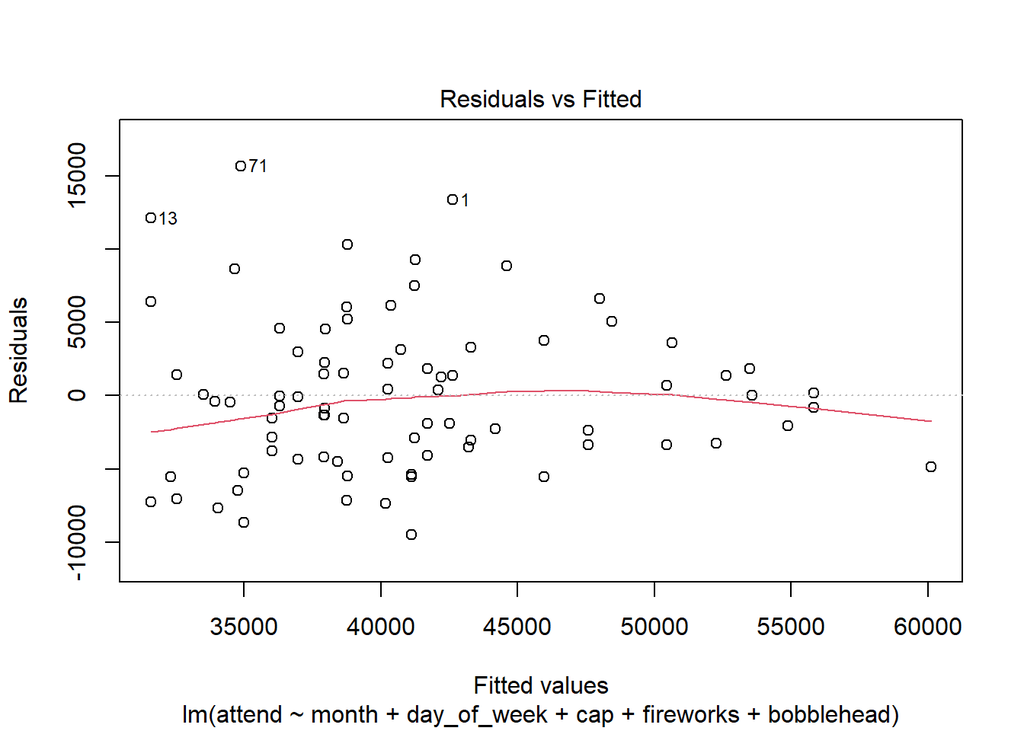

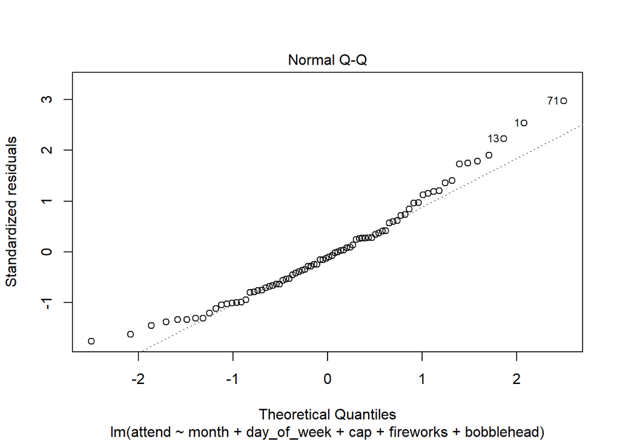

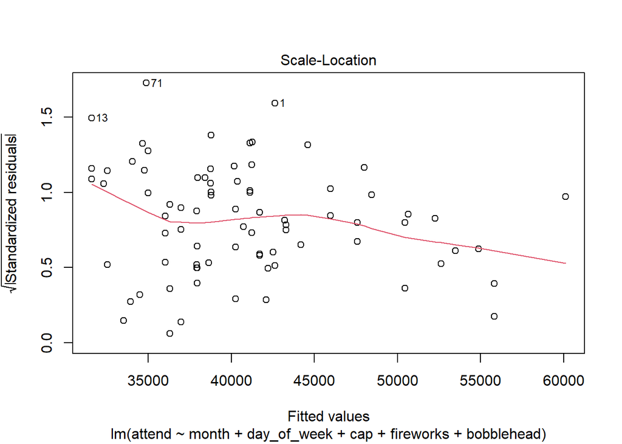

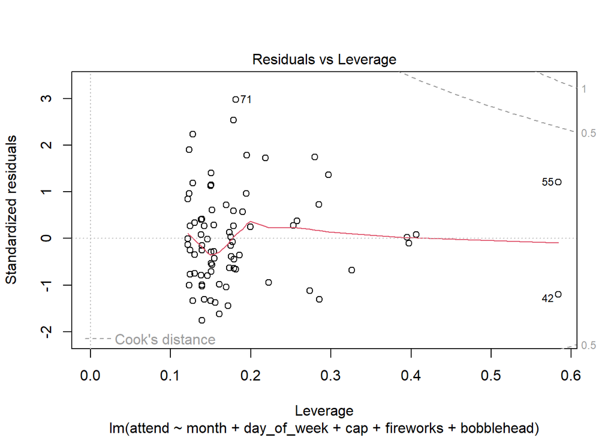

```r
plot(model3)
```

```r
anova(update(model3, . ~ . - shirt), model3)
```

```
## Analysis of Variance Table
##
## Model 1: attend ~ month + day_of_week + cap + fireworks + bobblehead
## Model 2: attend ~ month + day_of_week + cap + fireworks + bobblehead
##   Res.Df        RSS Df Sum of Sq F Pr(>F)
## 1     65 2201411129
## 2     65 2201411129  0         0
```

```r
AIC(model3)
```

```
## [1] 1650.419
```

```r
anova(model0,model3)
```

```
## Analysis of Variance Table
##
## Model 1: attend ~ month + day + day_of_week + opponent + skies + day_night +
##     cap + shirt + fireworks + bobblehead + pmax(0, temp - 24)
## Model 2: attend ~ month + day_of_week + cap + fireworks + bobblehead
##   Res.Df        RSS  Df  Sum of Sq      F Pr(>F)
## 1     44 1515720891
## 2     65 2201411129 -21 -685690237 0.9479 0.5385
```

Using ANOVA function it is observed that these models are statistically equivalent in terms of point prediction. However, AIC score is improved, which is more important for the purpose of this project.

For further improvement, the high correlation observed between bobblehead, month, and day of the week was utilized. So the model was modified with a more complex model. Then all of the other variables were tested once again to ensure none of the effects of variables were overlooked, and within the model and shirt, skies, and temp were found to decrease r^2 and increase the error, so they were omitted in the final model. Same ANOVA method was used to see if all the variables were infact crucial in the model. Significant variables were again checked with ANOVA function.  
(Note: Final model is named model2, not model3)

```r
model2 <-lm(formula = attend ~ month * day_of_week  *bobblehead+cap+fireworks+opponent, data = events)
model2 %>% summary()
```

```
##
## Call:
## lm(formula = attend ~ month * day_of_week * bobblehead + cap +
##     fireworks + opponent, data = events)
##
## Residuals:
##     Min      1Q  Median      3Q     Max
## -5866.4  -645.7     0.0   703.0  6061.0
##
## Coefficients: (54 not defined because of singularities)
##                                             Estimate Std. Error t value
## (Intercept)                                    42811      11910   3.595
## monthMAY                                       29686      15717   1.889
## monthJUN                                        7748      11242   0.689
## monthJUL                                       32687      16406   1.992
## monthAUG                                       26617      14349   1.855
## monthSEP                                       12878       8847   1.456
## monthOCT                                       22977      15740   1.460
## day_of_weekTuesday                             19789       5200   3.805
## day_of_weekWednesday                           -2182       5200  -0.419
## day_of_weekThursday                            -5733       6809  -0.842
## day_of_weekFriday                              -4700      11528  -0.408
## day_of_weekSaturday                            25887       8847   2.926
## day_of_weekSunday                              16994       7157   2.375
## bobbleheadYES                                  -4107       6809  -0.603
## capYES                                        -11904       5147  -2.313
## fireworksYES                                   16343       7279   2.245
## opponentAstros                                -41456      19596  -2.116
## opponentBraves                                -16435      12542  -1.310
## opponentBrewers                               -36967      19882  -1.859
## opponentCardinals                             -35609      19496  -1.827
## opponentCubs                                  -34515      22468  -1.536
## opponentGiants                                -32164      19428  -1.656
## opponentMarlins                               -42024      23050  -1.823
## opponentMets                                   -9880       9878  -1.000
## opponentNationals                             -10350      14497  -0.714
## opponentPadres                                -22150      13954  -1.587
## opponentPhillies                              -40769      22221  -1.835
## opponentPirates                                -8750      13143  -0.666
## opponentReds                                  -43497      21309  -2.041
```

[output cut: 195 more lines]

```
## monthAUG:day_of_weekSaturday:bobbleheadYES        NA
## monthSEP:day_of_weekSaturday:bobbleheadYES        NA
## monthOCT:day_of_weekSaturday:bobbleheadYES        NA
## monthMAY:day_of_weekSunday:bobbleheadYES          NA
## monthJUN:day_of_weekSunday:bobbleheadYES          NA
## monthJUL:day_of_weekSunday:bobbleheadYES          NA
## monthAUG:day_of_weekSunday:bobbleheadYES          NA
## monthSEP:day_of_weekSunday:bobbleheadYES          NA
## monthOCT:day_of_weekSunday:bobbleheadYES          NA
## ---
## Signif. codes:  0 '***' 0.001 '**' 0.01 '*' 0.05 '.' 0.1 ' ' 1
##
## Residual standard error: 3931 on 19 degrees of freedom
## Multiple R-squared:  0.9467, Adjusted R-squared:  0.7755
## F-statistic: 5.531 on 61 and 19 DF,  p-value: 0.00007043
```

```r
  anova(update(model2, . ~ . - fireworks), model2)
```

```
## Analysis of Variance Table
##
## Model 1: attend ~ month + day_of_week + bobblehead + cap + opponent +
##     month:day_of_week + month:bobblehead + day_of_week:bobblehead +
##     month:day_of_week:bobblehead
## Model 2: attend ~ month * day_of_week * bobblehead + cap + fireworks +
##     opponent
##   Res.Df       RSS Df Sum of Sq      F  Pr(>F)
## 1     20 371517330
## 2     19 293619102  1  77898229 5.0408 0.03685 *
## ---
## Signif. codes:  0 '***' 0.001 '**' 0.01 '*' 0.05 '.' 0.1 ' ' 1
```

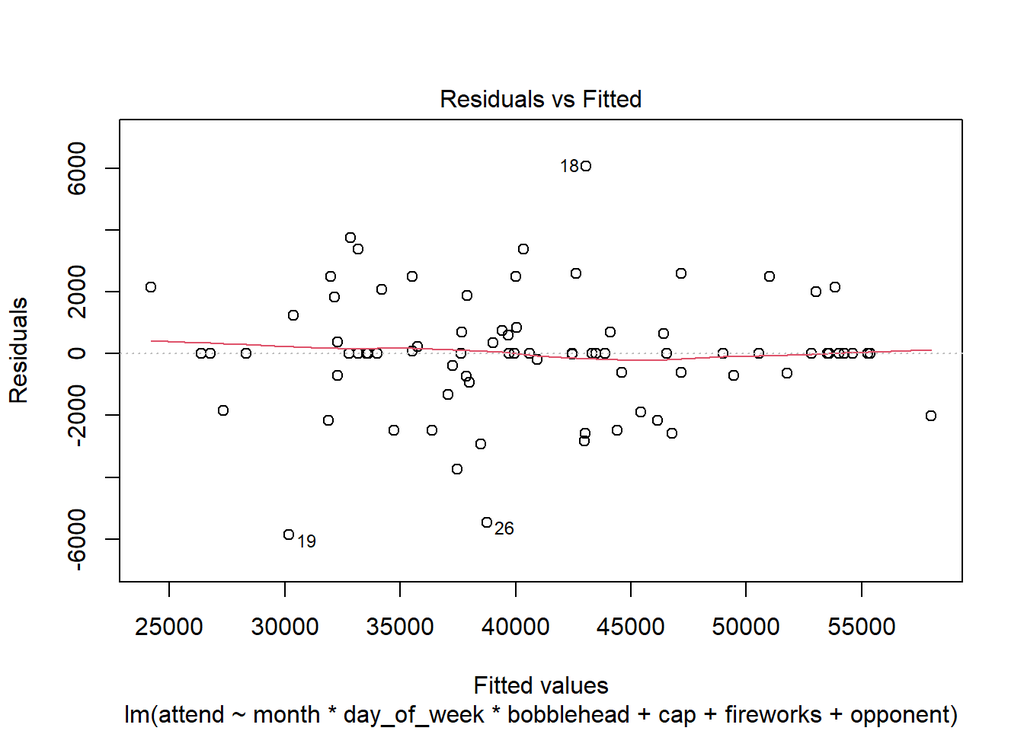

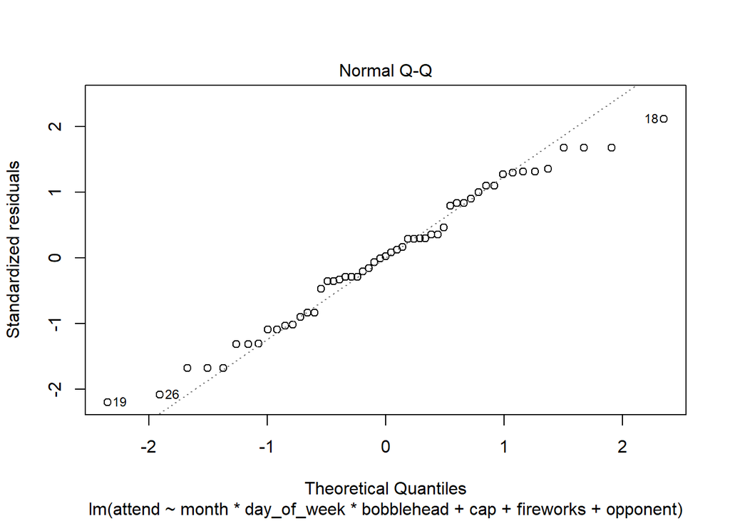

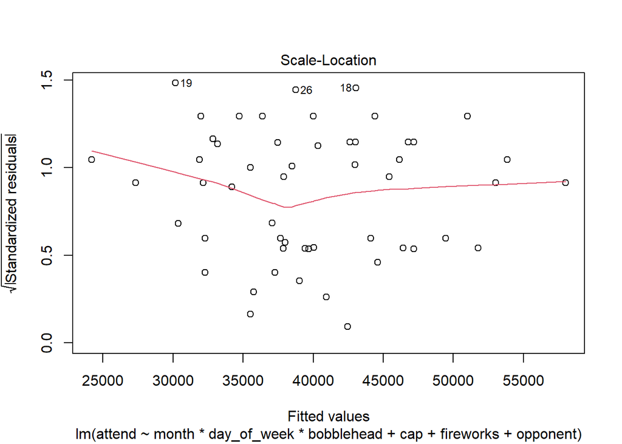

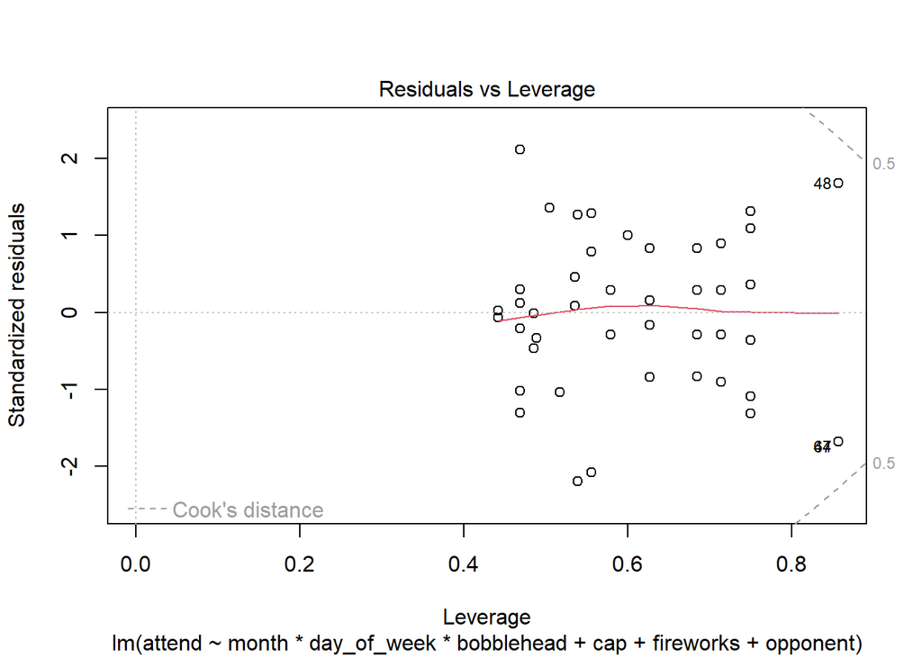

```r
plot(model2)
```

```r
anova(model2,model0)
```

```
## Analysis of Variance Table
##
## Model 1: attend ~ month * day_of_week * bobblehead + cap + fireworks +
##     opponent
## Model 2: attend ~ month + day + day_of_week + opponent + skies + day_night +
##     cap + shirt + fireworks + bobblehead + pmax(0, temp - 24)
##   Res.Df        RSS  Df   Sum of Sq      F   Pr(>F)
## 1     19  293619102
## 2     44 1515720891 -25 -1222101789 3.1633 0.006243 **
## ---
## Signif. codes:  0 '***' 0.001 '**' 0.01 '*' 0.05 '.' 0.1 ' ' 1
```

```r
anova(model2,model1)
```

```
## Analysis of Variance Table
##
## Model 1: attend ~ month * day_of_week * bobblehead + cap + fireworks +
##     opponent
## Model 2: attend ~ month + day_of_week + opponent + bobblehead
##   Res.Df        RSS  Df   Sum of Sq      F   Pr(>F)
## 1     19  293619102
## 2     51 2017425853 -32 -1723806751 3.4858 0.002869 **
## ---
## Signif. codes:  0 '***' 0.001 '**' 0.01 '*' 0.05 '.' 0.1 ' ' 1
```

```r
anova(model2,model3)
```

```
## Analysis of Variance Table
##
## Model 1: attend ~ month * day_of_week * bobblehead + cap + fireworks +
##     opponent
## Model 2: attend ~ month + day_of_week + cap + fireworks + bobblehead
##   Res.Df        RSS  Df   Sum of Sq      F  Pr(>F)
## 1     19  293619102
## 2     65 2201411129 -46 -1907792027 2.6838 0.01097 *
## ---
## Signif. codes:  0 '***' 0.001 '**' 0.01 '*' 0.05 '.' 0.1 ' ' 1
```

```r
AIC(model2)
```

```
## [1] 1579.239
```

For the final steps, with ANOVA function the point prediction difference of each model is checked with regards to final model, and its seen that statistically final model is different from the other models. Then AIC score is checked and its found that it is the lowest among all the other models.

```r
anova(update(model2, . ~ . - bobblehead), model2)
```

```
## Analysis of Variance Table
##
## Model 1: attend ~ month + day_of_week + cap + fireworks + opponent + month:day_of_week +
##     month:bobblehead + day_of_week:bobblehead + month:day_of_week:bobblehead
## Model 2: attend ~ month * day_of_week * bobblehead + cap + fireworks +
##     opponent
##   Res.Df       RSS Df     Sum of Sq F Pr(>F)
## 1     19 293619102
## 2     19 293619102  0 0.00000035763
```

Then R^2 score, RSE, and percentage errors are found:

R^2:

```r
round(100*summary(model2)$adj.r.squared)
```

```
## [1] 78
```

RSE:

```r
sigma(model2)
```

```
## [1] 3931.111
```

Percentage Error:

```r
100*sigma(model2)/56000
```

```
## [1] 7.019842
```

```r
update(model2, contrast = list(month = "contr.sum", bobblehead = "contr.sum")) %>% coef()
```

```
##                             (Intercept)                                  month1
##                               63440.482                              -22682.553
##                                  month2                                  month3
##                               20949.936                              -11194.196
##                                  month4                                  month5
##                               13745.483                                7675.238
##                                  month6                      day_of_weekTuesday
##                               -6063.594                                9024.920
##                    day_of_weekWednesday                     day_of_weekThursday
##                                1563.473                               23228.373
##                       day_of_weekFriday                     day_of_weekSaturday
##                                3000.151                               22393.174
##                       day_of_weekSunday                             bobblehead1
##                               16994.174                               -1687.286
##                                  capYES                            fireworksYES
##                              -11903.857                               16342.571
##                          opponentAstros                          opponentBraves
##                              -41456.325                              -16435.429
##                         opponentBrewers                       opponentCardinals
##                              -36967.236                              -35608.975
##                            opponentCubs                          opponentGiants
##                              -34515.036                              -32164.193
##                         opponentMarlins                            opponentMets
##                              -42024.322                               -9880.174
##                       opponentNationals                          opponentPadres
##                              -10349.602                              -22149.602
##                        opponentPhillies                         opponentPirates
##                              -40769.393                               -8750.429
##                            opponentReds                         opponentRockies
##                              -43496.965                              -37155.674
##                          opponentSnakes                       opponentWhite Sox
##                              -42318.679                              -14049.174
##               month1:day_of_weekTuesday               month2:day_of_weekTuesday
##                               10763.580                              -16558.763
##               month3:day_of_weekTuesday               month4:day_of_weekTuesday
##                               -7679.492                                7252.508
##               month5:day_of_weekTuesday               month6:day_of_weekTuesday
##                                8344.008                               -1945.920
##             month1:day_of_weekWednesday             month2:day_of_weekWednesday
##                               -3744.973                               -9743.794
```

[output cut: 61 more lines]

```
##                                      NA                                      NA
##    month5:day_of_weekFriday:bobblehead1    month6:day_of_weekFriday:bobblehead1
##                                      NA                                      NA
##  month1:day_of_weekSaturday:bobblehead1  month2:day_of_weekSaturday:bobblehead1
##                                      NA                                      NA
##  month3:day_of_weekSaturday:bobblehead1  month4:day_of_weekSaturday:bobblehead1
##                                      NA                                      NA
##  month5:day_of_weekSaturday:bobblehead1  month6:day_of_weekSaturday:bobblehead1
##                                      NA                                      NA
##    month1:day_of_weekSunday:bobblehead1    month2:day_of_weekSunday:bobblehead1
##                                      NA                                      NA
##    month3:day_of_weekSunday:bobblehead1    month4:day_of_weekSunday:bobblehead1
##                                      NA                                      NA
##    month5:day_of_weekSunday:bobblehead1    month6:day_of_weekSunday:bobblehead1
##                                      NA                                      NA
```

```r
update(model2, contrast = list(month = "contr.sum", bobblehead = "contr.sum")) %>% coef()
```

[output not shown]

[output cut: 61 more lines]

[output not shown]

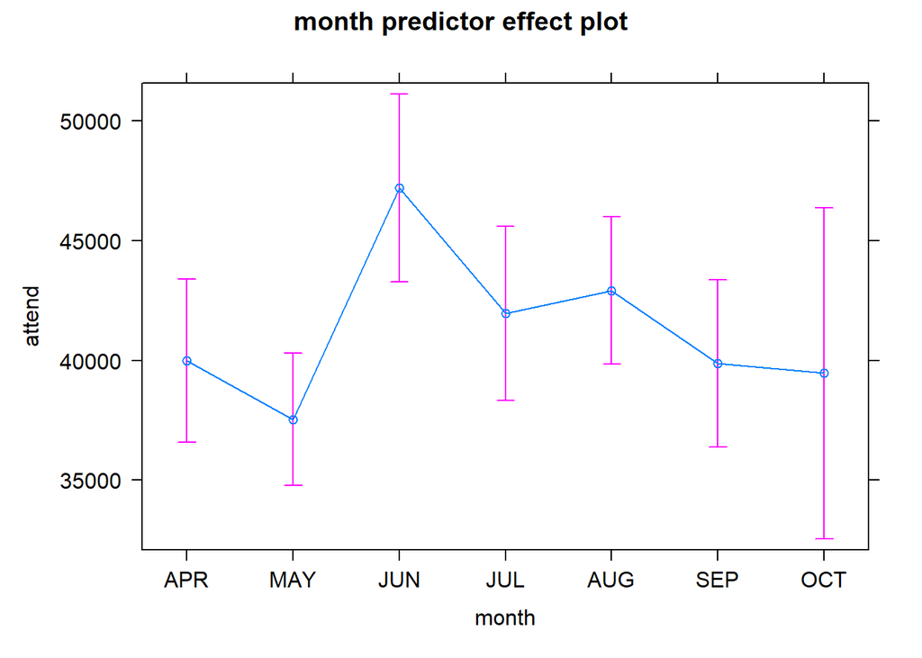

```r
effects::predictorEffect("month", model3) %>% plot()
```

```r
summary(model2) %>%
  coef() %>%
  as_tibble(rownames = "Predictor") %>%
  arrange(`Pr(>|t|)`) %>%
  pander(caption = "Summary")
```

Summary

| Predictor | Estimate | Std. Error | t value | Pr(>\|t\|) |
| --- | --- | --- | --- | --- |
| monthMAY:day_of_weekTuesday | -27322 | 7129 | -3.832 | 0.001124 |
| day_of_weekTuesday | 19789 | 5200 | 3.805 | 0.001195 |
| (Intercept) | 42811 | 11910 | 3.595 | 0.001932 |
| monthAUG:day_of_weekThursday | 37351 | 11039 | 3.383 | 0.003119 |
| monthMAY:bobbleheadYES | 27894 | 8758 | 3.185 | 0.004875 |
| day_of_weekSaturday | 25887 | 8847 | 2.926 | 0.008665 |
| monthJUN:day_of_weekSaturday | -19768 | 7354 | -2.688 | 0.01456 |
| monthSEP:day_of_weekThursday | 28961 | 10876 | 2.663 | 0.01537 |
| monthSEP:day_of_weekWednesday | 19201 | 7613 | 2.522 | 0.02074 |
| monthMAY:day_of_weekSaturday | -23751 | 9993 | -2.377 | 0.02813 |
| day_of_weekSunday | 16994 | 7157 | 2.375 | 0.02826 |
| capYES | -11904 | 5147 | -2.313 | 0.0321 |
| fireworksYES | 16343 | 7279 | 2.245 | 0.03685 |
| opponentSnakes | -42319 | 19972 | -2.119 | 0.04749 |
| opponentAstros | -41456 | 19596 | -2.116 | 0.04781 |
| opponentReds | -43497 | 21309 | -2.041 | 0.05536 |
| monthJUL | 32687 | 16406 | 1.992 | 0.0609 |
| monthAUG:day_of_weekSaturday | -13610 | 7009 | -1.942 | 0.06713 |
| opponentRockies | -37156 | 19362 | -1.919 | 0.07014 |
| monthMAY | 29686 | 15717 | 1.889 | 0.07429 |
| opponentBrewers | -36967 | 19882 | -1.859 | 0.07853 |
| monthAUG | 26617 | 14349 | 1.855 | 0.07918 |
| monthJUL:day_of_weekSunday | -30628 | 16523 | -1.854 | 0.07939 |
| opponentPhillies | -40769 | 22221 | -1.835 | 0.08226 |
| opponentCardinals | -35609 | 19496 | -1.827 | 0.08353 |
| opponentMarlins | -42024 | 23050 | -1.823 | 0.08406 |
| monthSEP:day_of_weekTuesday | -12709 | 7613 | -1.67 | 0.1114 |
| monthJUL:day_of_weekSaturday | -28597 | 17195 | -1.663 | 0.1127 |
| opponentGiants | -32164 | 19428 | -1.656 | 0.1142 |
| opponentPadres | -22150 | 13954 | -1.587 | 0.1289 |
| opponentWhite Sox | -14049 | 9062 | -1.55 | 0.1376 |
| opponentCubs | -34515 | 22468 | -1.536 | 0.141 |
| monthOCT | 22977 | 15740 | 1.46 | 0.1607 |
| monthSEP | 12878 | 8847 | 1.456 | 0.1618 |
| monthOCT:day_of_weekTuesday | -10939 | 7613 | -1.437 | 0.167 |
| monthSEP:day_of_weekFriday | 7701 | 5396 | 1.427 | 0.1698 |
| monthJUN:day_of_weekThursday | 18167 | 13795 | 1.317 | 0.2035 |
| opponentBraves | -16435 | 12542 | -1.31 | 0.2057 |
| monthJUL:day_of_weekFriday | -21118 | 16985 | -1.243 | 0.2289 |
| monthAUG:day_of_weekWednesday | 7917 | 6371 | 1.243 | 0.2291 |
| monthMAY:day_of_weekSunday | -9273 | 8534 | -1.087 | 0.2908 |
| monthJUN:day_of_weekTuesday | -10961 | 10213 | -1.073 | 0.2966 |
| opponentMets | -9880 | 9878 | -1 | 0.3298 |
| monthJUL:day_of_weekWednesday | 7407 | 7466 | 0.9921 | 0.3336 |
| monthMAY:day_of_weekWednesday | -5999 | 6381 | -0.9401 | 0.359 |
| monthMAY:day_of_weekFriday | -8472 | 9395 | -0.9017 | 0.3785 |
| day_of_weekThursday | -5733 | 6809 | -0.842 | 0.4103 |
| monthJUN:day_of_weekFriday | -5139 | 6519 | -0.7883 | 0.4402 |
| monthJUL:bobbleheadYES | 7482 | 9967 | 0.7506 | 0.4621 |
| opponentNationals | -10350 | 14497 | -0.7139 | 0.484 |
| monthJUN | 7748 | 11242 | 0.6891 | 0.4991 |
| opponentPirates | -8750 | 13143 | -0.6658 | 0.5136 |
| monthJUN:day_of_weekWednesday | -4883 | 7613 | -0.6415 | 0.5289 |
| bobbleheadYES | -4107 | 6809 | -0.6032 | 0.5535 |
| monthSEP:day_of_weekSaturday | -3494 | 6111 | -0.5717 | 0.5742 |
| monthAUG:day_of_weekTuesday | 5062 | 9426 | 0.537 | 0.5975 |
| monthJUL:day_of_weekTuesday | -3511 | 7009 | -0.501 | 0.6221 |
| day_of_weekWednesday | -2181 | 5200 | -0.4195 | 0.6796 |
| day_of_weekFriday | -4700 | 11528 | -0.4077 | 0.688 |
| monthMAY:day_of_weekThursday | -3024 | 8431 | -0.3586 | 0.7238 |
| monthOCT:day_of_weekWednesday | 2571 | 7613 | 0.3378 | 0.7392 |
| monthAUG:day_of_weekFriday | -1130 | 6126 | -0.1844 | 0.8556 |

```r
newdata = data.frame(month = "JUN",day_of_week="Friday",cap="YES",bobblehead="YES",fireworks="YES",shirt="YES",opponent="Cardinals",temp=mean(events$temp))
predict(model2, newdata = newdata, interval = "prediction", level = 0.90)
```

```
##        fit       lwr     upr
## 1 5442.342 -25583.12 36467.8
```

## Conclusions

The final model included month, day_of_week, bobblehead, cap, firework, and opponent variables. It was seen that some of the variables that were previously deemed to be important for the attendance prediction were actually not that relevant (temperature), and vice versa was also true. The fireworks variable was not deemed to be that relevant in the initial review, but later turned out to be a useful variable in the final model. Finally, it was seen that bobblehead affected the attendance and its effect was positively corrlated with attendance.

For better results individual opponent analysis might be done, as the effects of teams in cap, shirts, and bobblehead variables vary substantially. Also the cap, shirt, skies, and bobblehead variables have unbalanced amount of data in among their categories, which might introduce bias and reduce the effectiveness of predictions. Gaining more information about these variables would make the predictions more accurate.